# 🎯 Project Title: Sentiment Analysis on Internship Feedback

### 🔍 Objective

To evaluate the emotional tone of intern feedback through sentiment analysis, aiming to identify strengths and improvement areas for enhancing the internship experience

### 🛠 Tools & Libraries

- **Python**: Core programming language
- **Pandas**: Data manipulation and analysis
- **NLTK**: Natural Language Toolkit (used for sentiment analysis)
- **VADER (SentimentIntensityAnalyzer)**: For classifying sentiment
- **Matplotlib**: Data visualization
- **WordCloud**: For visualizing frequent words by entiment

### ✍️ Sample Feedback

Here are a few randomly selected feedback entries:

- “I really enjoyed the team sessions.” → **Positive**
- “The tasks were unclear and confusing.” → **Negative**

### 🔢 Sentiment Scoring Logic

Using VADER's compound score:

- Compound ≥ **0.05** → **Positive**
- Compound ≤ **-0.05** → **Negative**
- Otherwise → **Neutral**

## Import Libraries

```python
# python
import pandas as pd
import nltk
from nltk.sentiment import SentimentIntensityAnalyzer
import matplotlib.pyplot as plt
from wordcloud import WordCloud
from collections import Counter
import re

nltk.download('vader_lexicon')
```

### Data Loading

```python
df = pd.read_excel('Internship_Feedback_Demo_1000.xlsx')  # Update path if needed
df.head()
```

|  | Feedback |
| --- | --- |
| 0 | Loved the team environment and encouragement. |
| 1 | I had an amazing learning experience during th... |
| 2 | This internship boosted my confidence in data ... |
| 3 | Hands-on projects were really insightful. |
| 4 | It was okay, could be better with more tasks. |

**Explanation:**

- This line loads the data from an Excel file called `Internship_Feedback_Demo_1000.xlsx` into a DataFrame named `df`. You can change the file path if necessary.
- The `df.head()` function shows the first 5 rows of the data to help you quickly check what the dataset looks like.

## Exploratory Data Analysis

```python
print(" ")
print("Total feedback entries:", df.shape[0])
print(" ")
```

```
Total feedback entries: 1100
```

**Explanation:**

- `df.shape[0]`: This retrieves the number of rows (feedback entries) in the DataFrame `df`.
- The `print` function displays the total number of feedback entries in the dataset.

```python
print(" ")
print("Sample feedback:")
print(" ")
print(df['Feedback'].sample(5))
print(" ")
```

```
Sample feedback:

803         It was a decent experience, nothing special.
686      The environment was not engaging or supportive.
467    I had an amazing learning experience during th...
462               Somewhat useful but lacked engagement.
399    The mentorship was outstanding and very suppor...
Name: Feedback, dtype: object
```

**Explanation:**

- `df['Feedback'].sample(5)`: This randomly selects 5 feedback entries from the 'Feedback' column in the DataFrame `df`.
- The `print` statements are used to display the message "Sample feedback:" followed by the randomly selected feedback entries.

### Check nulls or duplicates

```python
print(" ")
print("Missing Values:", df.isnull().sum())
print(" ")
print("Duplicate entries:", df.duplicated().sum())
print(" ")
```

[output not shown]

**Explanation:**

- `df.isnull().sum()`: This checks if there are any missing (null) values in the dataset and then sums up how many missing values are present in each column.
- `df.duplicated().sum()`: This checks for duplicate rows in the dataset and counts how many duplicate entries exist.
- The `print` statements display the number of missing values and duplicate entries in the dataset.

## Feature Engineering (Word & Character Counts)

```python
df['Word_Count'] = df['Feedback'].apply(lambda x: len(x.split()))
df['Char_Count'] = df['Feedback'].apply(len)
df[['Word_Count', 'Char_Count']].describe()
```

|  | Word_Count | Char_Count |
| --- | --- | --- |
| count | 1100.000000 | 1100.000000 |
| mean | 7.000909 | 46.564545 |
| std | 1.471290 | 6.894791 |
| min | 4.000000 | 33.000000 |
| 25% | 6.000000 | 41.000000 |
| 50% | 7.000000 | 45.000000 |
| 75% | 8.000000 | 51.000000 |
| max | 10.000000 | 59.000000 |

**Explanation:**

- `df['Word_Count'] = df['Feedback'].apply(lambda x: len(x.split()))`: This calculates the word count for each feedback entry by splitting the text into words and counting them.
- `df['Char_Count'] = df['Feedback'].apply(len)`: This calculates the character count for each feedback entry by measuring the length of the text.
- `df[['Word_Count', 'Char_Count']].describe()`: This generates summary statistics (like mean, standard deviation, min, max, etc.) for both the word and character counts across all feedback entries.

## Keyword Frequency

```python
print(" ")
all_words = ' '.join(df['Feedback']).lower()
all_words = re.sub(r'[^a-zA-Z ]', '', all_words).split()
word_freq = Counter(all_words)
print(word_freq.most_common(10))
```

```
[('the', 440), ('was', 384), ('and', 315), ('internship', 248), ('i', 247), ('not', 156), ('were', 147), ('tasks', 142), ('learning', 126), ('very', 119)]
```

**Explanation:**

- `all_words = ' '.join(df['Feedback']).lower()`: This combines all feedback entries into a single string and converts all text to lowercase for uniformity.
- `re.sub(r'[^a-zA-Z ]', '', all_words)`: This removes any characters that are not letters or spaces, ensuring that only words remain.
- `all_words.split()`: This splits the text into individual words.
- `word_freq = Counter(all_words)`: This counts the frequency of each word in the text.
- `word_freq.most_common(10)`: This displays the 10 most common words along with their frequencies in the dataset.

### Apply Sentiment Scoring

```python
sia = SentimentIntensityAnalyzer()
df['Sentiment_Score'] = df['Feedback'].apply(lambda x: sia.polarity_scores(x)['compound'])

def classify_sentiment(score):
    if score >= 0.05:
        return 'Positive'
    elif score <= -0.05:
        return 'Negative'
    else:
        return 'Neutral'

df['Sentiment'] = df['Sentiment_Score'].apply(classify_sentiment)
```

**Explanation:**

- Creates a `SentimentIntensityAnalyzer` object to perform sentiment analysis.
- Applies VADER to each row in the 'Feedback' column of the dataset.
- Extracts the compound score from the sentiment analysis result, which is a single number between -1 (most negative) and +1 (most positive).
- Saves the computed sentiment score in a new column called 'Sentiment_Score' for later analysis.

## Sentiment Distribution Analysis

```python
print(" ")
sentiment_counts = df['Sentiment'].value_counts()
print(sentiment_counts)
```

```
Sentiment
Positive    559
Negative    322
Neutral     219
Name: count, dtype: int64
```

**Explanation:**

- `df['Sentiment'].value_counts()`: This counts how many entries belong to each sentiment category (Positive, Negative, or Neutral) in the 'Sentiment' column.
- The `print` statement displays the count of each sentiment type in the dataset.

### Bar chart

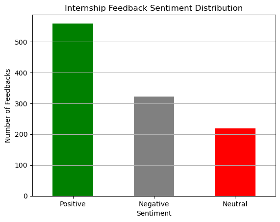

```python
colors = ['green', 'grey', 'red']
sentiment_counts.plot(kind='bar', color=colors)
plt.title('Internship Feedback Sentiment Distribution')
plt.xlabel('Sentiment')
plt.ylabel('Number of Feedbacks')
plt.xticks(rotation=0)
plt.grid(axis='y')
plt.show()
```

**Explanation:**

## WordClouds by Sentiment

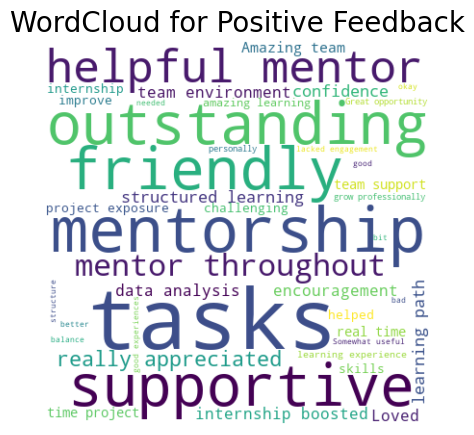

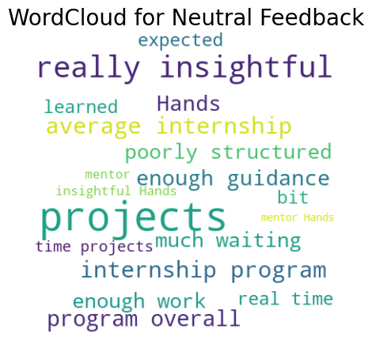

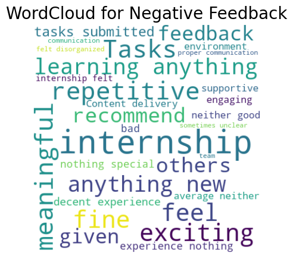

```python
for sentiment in ['Positive', 'Neutral', 'Negative']:
    text = ' '.join(df[df['Sentiment'] == sentiment]['Feedback'])
    wc = WordCloud(width=400, height=400, background_color='white').generate(text)
    plt.figure(figsize=(5, 5))
    plt.imshow(wc, interpolation='bilinear')
    plt.axis('off')
    plt.title(f'WordCloud for {sentiment} Feedback', fontsize=20)
    plt.show()
```

**Explanation:**

- `for sentiment in ['Positive', 'Neutral', 'Negative']`: This loop goes through each sentiment category (Positive, Neutral, Negative).
- `text = ' '.join(df[df['Sentiment'] == sentiment]['Feedback'])`: For each sentiment, it combines all feedback entries belonging to that sentiment into a single text block.
- `wc = WordCloud(width=400, height=400, background_color='white').generate(text)`: This generates a WordCloud from the combined text for the current sentiment, with a white background and a size of 400x400 pixels.
- `plt.figure(figsize=(5, 5))`: Sets the figure size for displaying the WordCloud.
- `plt.imshow(wc, interpolation='bilinear')`: Displays the WordCloud using bilinear interpolation for smoother image rendering.
- `plt.axis('off')`: Hides the axis for a cleaner visual.
- `plt.title(f'WordCloud for {sentiment} Feedback', fontsize=20)`: Adds a title to the WordCloud indicating the sentiment type (Positive, Neutral, or Negative).
- `plt.show()`: Displays the generated WordCloud for the current sentiment.

## Enhanced Analysis – Top Feedback Samples

```python
print(" ")
print("Top Positive Feedbacks:")
print(" ")
print(df.sort_values('Sentiment_Score', ascending=False)['Feedback'].head(5))
print(" ")
print("Top Negative Feedbacks:")
print(" ")
print(df.sort_values('Sentiment_Score')['Feedback'].head(5))
```

```
Top Positive Feedbacks:

311     Great opportunity to grow professionally and p...
854     Great opportunity to grow professionally and p...
676     Great opportunity to grow professionally and p...
457     Great opportunity to grow professionally and p...
1047    Great opportunity to grow professionally and p...
Name: Feedback, dtype: object

Top Negative Feedbacks:

971    Content delivery was average, neither good nor...
924    Content delivery was average, neither good nor...
455    Content delivery was average, neither good nor...
148    Content delivery was average, neither good nor...
308    Content delivery was average, neither good nor...
Name: Feedback, dtype: object
```

**Explanation:**

- `df.sort_values('Sentiment_Score', ascending=False)['Feedback'].head(5)`: This sorts the feedback entries in descending order based on their sentiment score (from most positive to least positive) and then displays the top 5 positive feedback entries.
- `df.sort_values('Sentiment_Score')['Feedback'].head(5)`: This sorts the feedback entries in ascending order based on their sentiment score (from most negative to least negative) and then displays the top 5 negative feedback entries.
- The `print` statements are used to display the labels "Top Positive Feedbacks" and "Top Negative Feedbacks," followed by the actual feedback entries.

## Enhanced Analysis – Theme Analysis by Keywords

```python
themes = {
    'Mentorship': ['mentor', 'mentorship', 'guide'],
    'Communication': ['communication', 'reply', 'response'],
    'Projects': ['project', 'task', 'assignment'],
    'Learning': ['learn', 'knowledge', 'skills'],
    'Support': ['help', 'support', 'assist']
}

def check_theme(text, keywords):
    text = text.lower()
    return any(keyword in text for keyword in keywords)

for theme, keywords in themes.items():
    df[theme] = df['Feedback'].apply(lambda x: check_theme(x, keywords))

theme_sentiments = {}
for theme in themes.keys():
    avg_score = df[df[theme]]['Sentiment_Score'].mean()
    theme_sentiments[theme] = round(avg_score, 3)
print(" ")
print("Average Sentiment by Theme:")
print(theme_sentiments)
```

```
Average Sentiment by Theme:
{'Mentorship': 0.595, 'Communication': -0.274, 'Projects': 0.203, 'Learning': 0.367, 'Support': 0.597}
```

**Explanation:**

- `themes`: A dictionary that defines specific themes (e.g., Mentorship, Communication) and the related keywords for each theme.
- `check_theme(text, keywords)`: A function that checks if any of the keywords for a theme are present in the feedback text. It converts the text to lowercase and searches for any matching keyword.
- `df[theme] = df['Feedback'].apply(lambda x: check_theme(x, keywords))`: For each theme, this line applies the `check_theme` function to the 'Feedback' column, creating a new column for each theme (e.g., 'Mentorship', 'Communication') in the DataFrame, marking `True` for feedback that mentions the theme and `False` otherwise.
- `theme_sentiments = {}`: A dictionary to store the average sentiment score for each theme.
- `avg_score = df[df[theme]]['Sentiment_Score'].mean()`: This calculates the average sentiment score for feedback that mentions a particular theme.
- `theme_sentiments[theme] = round(avg_score, 3)`: Stores the rounded average sentiment score for each theme in the `theme_sentiments` dictionary.
- The `print` statements display the average sentiment scores for each theme in the dataset.

## Enhanced Analysis – Program Sentiment Score

```python
score_map = {'Positive': 1, 'Neutral': 0, 'Negative': -1}
df['Sentiment_Score_Mapped'] = df['Sentiment'].map(score_map)
overall_score = df['Sentiment_Score_Mapped'].mean()
print(" ")
print(f"Overall Program Sentiment Score: {round(overall_score, 2)}")
print(" ")
```

```
Overall Program Sentiment Score: 0.22
```

**Explanation:**

- `score_map = {'Positive': 1, 'Neutral': 0, 'Negative': -1}`: This creates a mapping where 'Positive' is assigned a score of 1, 'Neutral' is assigned 0, and 'Negative' is assigned -1.
- `df['Sentiment_Score_Mapped'] = df['Sentiment'].map(score_map)`: This applies the `score_map` to the 'Sentiment' column, creating a new column `Sentiment_Score_Mapped` with the corresponding numerical values for each sentiment.
- `overall_score = df['Sentiment_Score_Mapped'].mean()`: This calculates the average of the mapped sentiment scores to obtain the overall sentiment score for the program.
- The `print` statement displays the overall sentiment score, rounded to two decimal places.

```python
# Define themes and related keywords
themes = {
    'Mentorship': ['mentor', 'mentorship', 'guide'],
    'Communication': ['communication', 'reply', 'response'],
    'Projects': ['project', 'task', 'assignment'],
    'Learning': ['learn', 'knowledge', 'skills'],
    'Support': ['help', 'support', 'assist']
}

# Function to check sentiment score for each theme
def analyze_sentiment_by_theme(df, themes):
    for theme, keywords in themes.items():
        df[theme] = df['Feedback'].apply(lambda x: any(keyword in x.lower() for keyword in keywords))
        sentiment_score = df[df[theme]]['Sentiment_Score'].mean()  # Average sentiment for the theme
        print(f"{theme} - Avg Sentiment Score: {sentiment_score}")
```

**Explanation:**

- `themes`: A dictionary defining specific themes (e.g., Mentorship, Communication) and the associated keywords for each theme.
- `analyze_sentiment_by_theme(df, themes)`: A function that calculates the average sentiment score for feedback related to each theme.
  - `df[theme] = df['Feedback'].apply(lambda x: any(keyword in x.lower() for keyword in keywords))`: This line checks if any of the keywords for the current theme are present in each feedback entry. If a keyword is found, it marks the theme as `True` for that feedback entry.
  - `sentiment_score = df[df[theme]]['Sentiment_Score'].mean()`: This calculates the average sentiment score for all feedback entries related to the current theme.
  - `print(f"{theme} - Avg Sentiment Score: {sentiment_score}")`: This prints the average sentiment score for the current theme.

## Export Results

```python
# Save full dataset
df.to_excel('Sentiment_Analysis_Results.xlsx', index=False)

# Save by sentiment
with pd.ExcelWriter('Sentiment_Feedback_Sheets.xlsx') as writer:
    df[df['Sentiment'] == 'Positive'].to_excel(writer, sheet_name='Positive', index=False)
    df[df['Sentiment'] == 'Neutral'].to_excel(writer, sheet_name='Neutral', index=False)
    df[df['Sentiment'] == 'Negative'].to_excel(writer, sheet_name='Negative', index=False)
```

**Explanation:**

- `df.to_excel('Sentiment_Analysis_Results.xlsx', index=False)`: This saves the entire dataset (`df`) with all columns, including the sentiment analysis results, to an Excel file named `Sentiment_Analysis_Results.xlsx`. The `index=False` argument ensures that the DataFrame index is not included in the saved file.
- `with pd.ExcelWriter('Sentiment_Feedback_Sheets.xlsx') as writer`: This opens a new Excel file called `Sentiment_Feedback_Sheets.xlsx` for writing multiple sheets.
  - `df[df['Sentiment'] == 'Positive'].to_excel(writer, sheet_name='Positive', index=False)`: This saves the feedback with a 'Positive' sentiment in a sheet named 'Positive'.
  - `df[df['Sentiment'] == 'Neutral'].to_excel(writer, sheet_name='Neutral', index=False)`: This saves the feedback with a 'Neutral' sentiment in a sheet named 'Neutral'.
  - `df[df['Sentiment'] == 'Negative'].to_excel(writer, sheet_name='Negative', index=False)`: This saves the feedback with a 'Negative' sentiment in a sheet named 'Negative'.

# Final Insights and Recommendations

### ✅ Recommendations:

- Strengthen **mentor check-ins** and feedback loops.
- Improve **onboarding** and task clarity for all departments.
- Run **monthly surveys** to continuously track intern eperience.